# Презентация по лабораторной работе №11

Дисциплина: Архитектура компьютеров и операционные системы

Гусев Степан Андреевич

1032242444@rudn.ru

Российский университет дружбы народов

2026-04-06

# Информация

**Презентация по лабораторной работе №11**

**Автор:** Гусев Степан Андреевич

**Преподаватель:** Кулябов Дмитрий Сергеевич, д.ф.-м.н., профессор кафедры теории вероятностей и кибербезопасности

Российский университет дружбы народов

## Докладчик

- Гусев Степан Андреевич
- Студент программы “Бизнес-информатика”
- Российский университет дружбы народов им. П. Лумумбы
- 1032242444@rudn.ru
- https://github.com/stepagusev

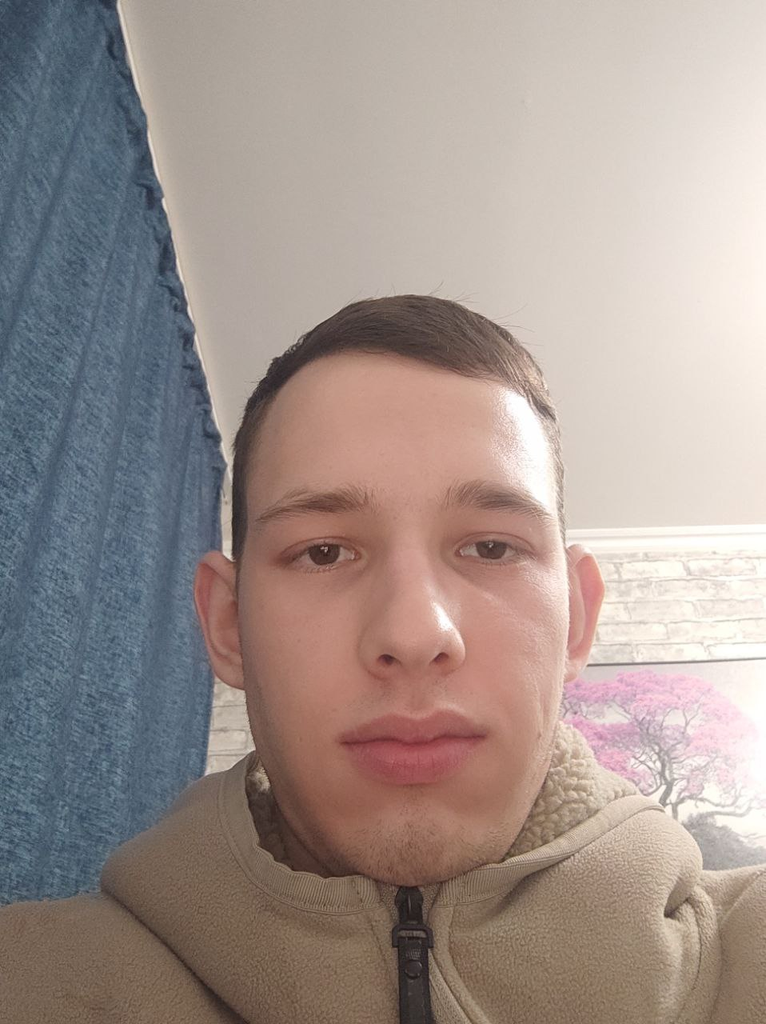

## Цель

Познакомиться с операционной системой Linux. Получить практические навыки работы с редактором Emacs.

## Задание

1. Ознакомиться с теоретическим материалом.
2. Ознакомиться с редактором emacs.
3. Выполнить упражнения.
4. Ответить на контрольные вопросы.

# Выполнение лабораторной работы

## Выполнение лабораторной работы

Открыл emacs.

## Выполнение лабораторной работы

Создал файл lab07.sh.

## Выполнение лабораторной работы

Ввёл нужный текст.

## Выполнение лабораторной работы

Сохранил файл.

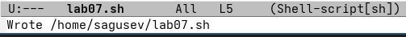

Рисунок 4: Сохранение файла

## Выполнение лабораторной работы

Вырезал строку и вставил её в конец файла.

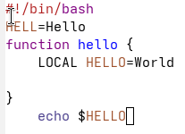

Рисунок 5: Редактирование файла

## Выполнение лабораторной работы

Выделил область текста.

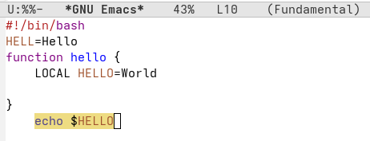

Рисунок 6: Выделение текста

## Выполнение лабораторной работы

Скопировал её и вставил в конец файла.

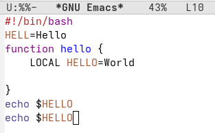

Рисунок 7: Редактирование файла

## Выполнение лабораторной работы

Снова выделил эту область и вырезал её.

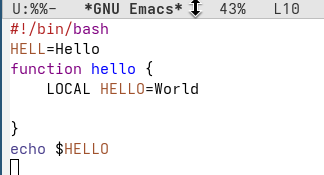

Рисунок 8: Вырезание текста

## Выполнение лабораторной работы

Отменил последнее действие.

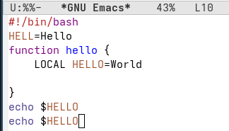

Рисунок 9: Отмена действия

## Выполнение лабораторной работы

Переместил курсор в начало строки.

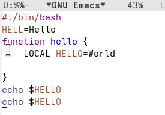

Рисунок 10: Начало строки

## Выполнение лабораторной работы

Переместил курсор в конец строки.

[figure not shown]

Рисунок 11: Конец строки

## Выполнение лабораторной работы

Переместил курсор в начало буфера.

[figure not shown]

Рисунок 12: Начало буфера

## Выполнение лабораторной работы

Переместил курсор в конец буфера.

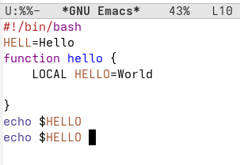

Рисунок 13: Конец буфера

## Выполнение лабораторной работы

Вывел список активных буферов на экран.

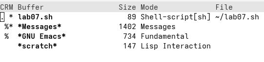

Рисунок 14: Вывод буферов

## Выполнение лабораторной работы

Переместился во вновь открытое окно и закрыл его.

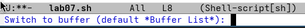

Рисунок 15: Закрытие окна

## Выполнение лабораторной работы

Поделил фрейм на четыре части.

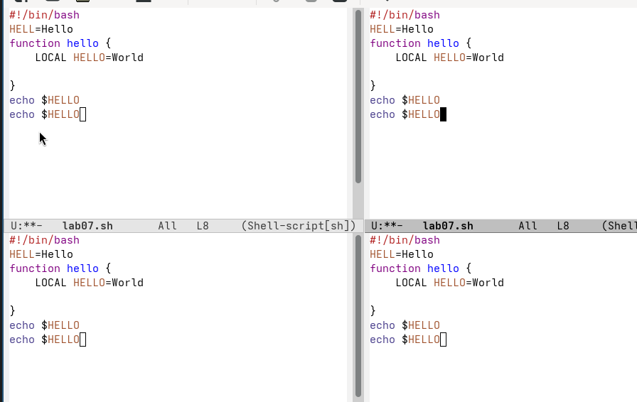

Рисунок 16: Четыре части

## Выполнение лабораторной работы

В каждом окне создал новый буфер и ввёл в них текст.

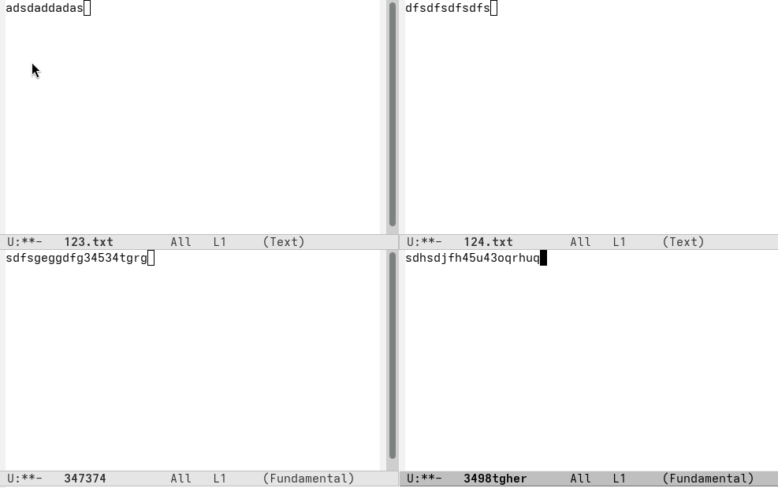

Рисунок 17: Четыре файла

## Выполнение лабораторной работы

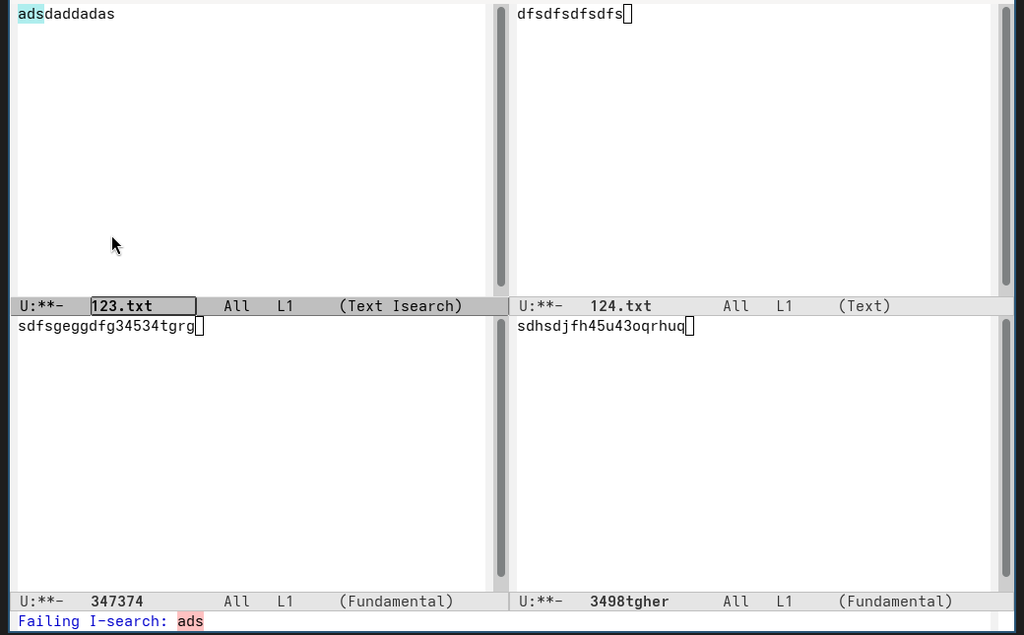

Рисунок 18: Режим поиска

## Выполнение лабораторной работы

Переключаюсь между результатами поиска.

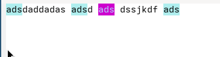

Рисунок 19: Переключение между результатами

## Выполнение лабораторной работы

Вышел из режима поиска.

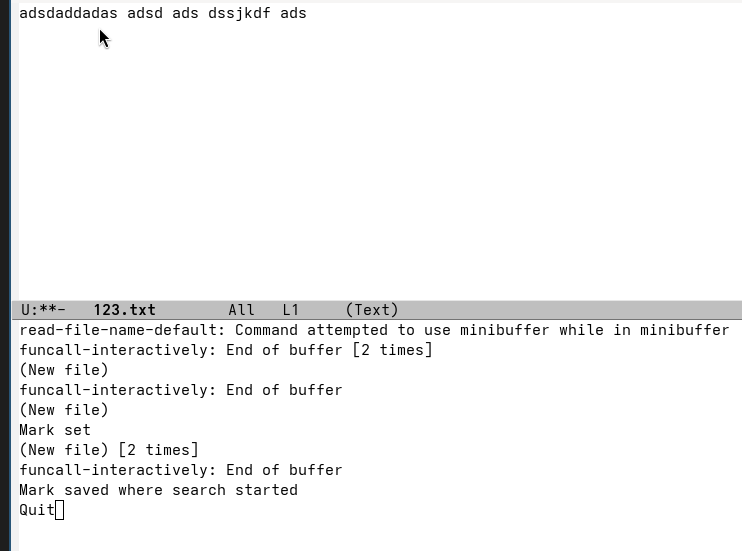

Рисунок 20: Выход из поиска

## Выполнение лабораторной работы

Попробовал другой режим поиска, нажав alt+s, o. Этот режим отключается тем, что это поиск по регулярным выражениям.

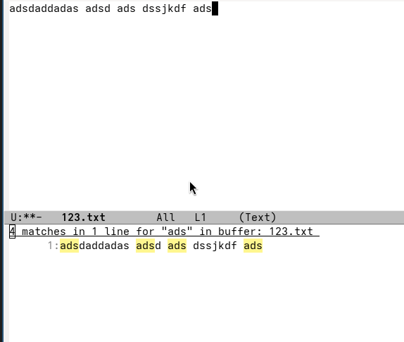

Рисунок 21: Поиск по регулярным выражениям

# Выводы

## Выводы

Я получил практические навыки работы с редактором Emacs.